# Skills Quiz: Confidence and Prediction Intervals

```r
pacman::p_load(readr, haven, readxl, downloader, tidyverse, ggbeeswarm, mosaic, stringr, pander, DT, ggplot2, pander, alr3)
```

## Instructions

Use this file to keep a record of your work as you complete the “Skills Quiz: Confidence and Prediction Intervals” assignment in Canvas.

## Problem 1 {Done}

Install the `alr3` library in R: `install.packages("alr3")`.

From `library(alr3)` open the `BGSall` data set in R. As stated in the help file for this data set, this data is a collection of measurements on “children born in 1928-29 in Berkeley, CA.”

`> ?BGSall`

`> View(BGSall)`

A standing tradition is that if you measure a child when they are 2-years old, and double their height, this will give a good prediction on their final adult height. Let’s see if this is true.

Perform a regression that could predict a child’s 18-year old height from their 2-year old height.

### Part (a) {done}

Type out the mathematical equation for this regression model and label both $Y$ and $X$ in the equation.

$$\underbrace{Y_i}_\text{18-Year Old Height} = \overbrace{\beta_0}^\text{Intercept} + \overbrace{\beta_1}^\text{Slope} \ \underbrace{X_i}_\text{2-Year Old Height} + \overbrace{\epsilon_i}^\text{Error Term} \quad \text{where} \ \epsilon_i \sim N(0,\sigma^2)$$

| Parameter | Explanation |
| --- | --- |
| $Y_i$ | 18-year old’s height |
| $\beta_0$ | Average 18-year old height when the height of a two-year old is zero cm. |
| $\beta_1$ | Change in the average 18-year olds’ height as centimeters gained by a child increases by 1. |
| $X_i$ | 2-year old’s height |
| $\epsilon_i$ | Each child’s height difference from the average 18-year old height. |

### Part (b) {done}

Plot a scatterplot of the data with your regression line overlaid. Write out the fitted regression equation.

```r
BGSall.lm <- lm(HT18 ~ HT2, data = BGSall)
BGSall.lm.co <- BGSall.lm$coefficients
#summary(BGSall.lm)
```

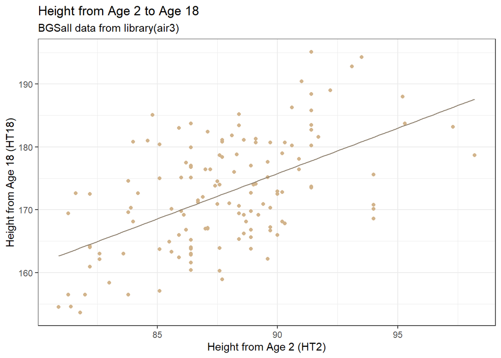

```r
BGSall %>%
  ggplot(aes(y = HT18, x = HT2)) +
  geom_point(color = "tan") +
  stat_function(fun = function(x){(BGSall.lm.co[1] + BGSall.lm.co[2]*x)}, color = "bisque4") +
  labs(title = "Height from Age 2 to Age 18",
       subtitle = "BGSall data from library(air3)",
       x = "Height from Age 2 (HT2)",
       y = "Height from Age 18 (HT18)") +
  theme_bw()
```

$$\underbrace{\hat{Y_i}}_\text{Estimated 18-Year Old Height} = \overbrace{b_0}^\text{Intercept Estimate} + \overbrace{b_1}^\text{Slope Estimate} \underbrace{X_i}_\text{2-Year Old Height}$$

### Part (c) {done}

Report the test statistics and p-values for the following hypotheses. (The hypotheses about $\beta_0$ claim that at age 0-years, a child should have height 0 cm. The hypotheses about $\beta_1$ claim that height doubles from age 2 to 18.)

$$\begin{array}{l}
H_0: \beta_0 = 0 \\
H_a: \beta_0 \neq 0 \\
\end{array} \quad
\begin{array}{l}
H_0: \beta_1 = 2 \\
H_a: \beta_1 \neq 2 \\
\end{array}$$

```r
#T-stat math formula: (Estimate (b_0 or b_1) - hypothesis number)/std.Error_{b_0 or b_1}
(45.7966 - 0)/16.7006 # Interc t-stat
```

```
## [1] 2.742213
```

```r
(1.4441 - 2)/0.1901 # Slope t-stat
```

```
## [1] -2.92425
```

```r
b_0.lm <- (45.7966 - 0)/16.7006
b_1.lm <- (1.4441 - 2)/0.1901
#P-value is hard to calculate use this: pt(-abs(tvalue), degrees of freedom)
pt(-abs(b_0.lm), 134)*2 # Interc p-value
```

```
## [1] 0.006937079
```

```r
pt(-abs(b_1.lm), 134)*2 # Slope p-value
```

```
## [1] 0.00405559
```

| Test | Test Statstic | P-value |
| --- | --- | --- |
| Intercept | 2.742213 | 0.006937079 |
| Slope | -2.92425 | 0.00405559 |

### Part (d) {done}

State the slope, y-intercept, and $R^2$ of this regression. Further, provide 95% confidence intervals for the slope and intercept. Interpret the values.
$$b_0 = \bar{Y} - b_1\bar{X}$$
$$b_1 = \frac{\sum X_i(Y_i - \bar{Y})} {\sum(X_i - \bar{X})^2}$$

$$R^2 = \frac{SSR =\sum_{i=1}^n (\hat{Y}_i - \bar{Y})^2}{SSTO = \sum_{i=1}^n (Y_i - \bar{Y})^2}$$

```r
b_1 <- ((sum(BGSall$HT2*(BGSall$HT18 - mean(BGSall$HT18)))) / (sum( (BGSall$HT2 - mean(BGSall$HT2))^2 )))
b_0 <- mean(BGSall$HT18) - b_1*mean(BGSall$HT2)
`R^2` <- ((sum( (BGSall.lm$fit - mean(BGSall$HT18))^2 )) / (sum( (BGSall$HT18 - mean(BGSall$HT18))^2 )))

confint(BGSall.lm, level = 0.95)
```

```
##                 2.5 %    97.5 %
## (Intercept) 12.765715 78.827522
## HT2          1.068108  1.820011
```

[output not shown]

### Part (e) {done}

Create a residuals vs fitted-values plot and Q-Q Plot of the residuals for this regression. What do these plots show?

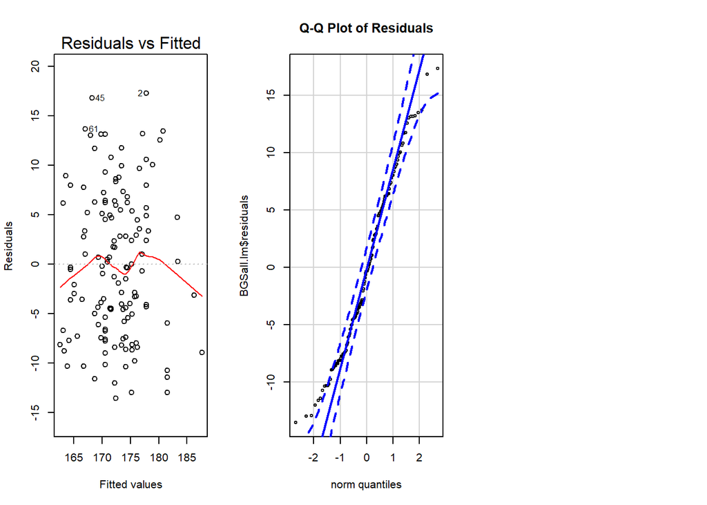

```r
# Check Assumptions
par(mfrow=c(1,3))
# plot(BGSall.lm, which=1:2)
# plot(BGSall.lm$residuals, main = "Residuals vs Order")
plot(BGSall.lm, which = 1)
qqPlot(BGSall.lm$residuals, main = "Q-Q Plot of Residuals", id = FALSE)
```

These plots show that variance of the error terms or residuals is normal while the linearity of the data is not normal. Most likely due to the outliers. Additionally, the probability plot shows us that the error terms are not normally distributed. An x-transformation will have to be created in order for this to work.

### Part (f) {done}

A certain stats teacher at BYU-Idaho has a son named Andrew who turns 2-years old in a couple of weeks. He is currently 2 feet 9 inches tall. Predict his 18-year old height in centimeters with 95% confidence.

```r
Andrew <- ((2*12)+9)*2.54
predict(BGSall.lm, data.frame(HT2=Andrew), interval="prediction")
```

```
##        fit      lwr     upr
## 1 166.8377 152.0294 181.646
```

## Problem 2

Open the `wblake` data set from library(alr3).

`> ?wblake`

`> View(wblake)`

If you love fishing, then you might like this data. The goal of this data was to see if there was a link in the radius size of a key “Scale” of a fish and the overall “Length” of the fish.

### Part (a) {done}

Type out the mathematical equation for this regression model and label both $Y$ and $X$ in the equation.

$$\underbrace{Y_i}_\text{Scale of a Fish} = \overbrace{\beta_0}^\text{Intercept} + \overbrace{\beta_1}^\text{Slope} \ \underbrace{X_i}_\text{Length of Fish} + \overbrace{\epsilon_i}^\text{Error Term} \quad \text{where} \ \epsilon_i \sim N(0,\sigma^2)$$

### Part (b) {done}

Plot a scatterplot of the data with your regression line overlaid. Write out the fitted regression equation. State the $R^2$ value of the regression.

```r
wblake.lm <- lm(Scale ~ Length, data = wblake)
wblake.lm.co <- wblake.lm$coefficients
pander(summary(wblake.lm))
```

|  | Estimate | Std. Error | t value | Pr(>\|t\|) |
| --- | --- | --- | --- | --- |
| **(Intercept)** | -1.431 | 0.1357 | -10.55 | 2.544e-23 |
| **Length** | 0.0378 | 0.0006644 | 56.9 | 3.706e-204 |

Fitting linear model: Scale ~ Length

| Observations | Residual Std. Error | $R^2$ | Adjusted $R^2$ |
| --- | --- | --- | --- |
| 439 | 0.9288 | 0.8811 | 0.8808 |

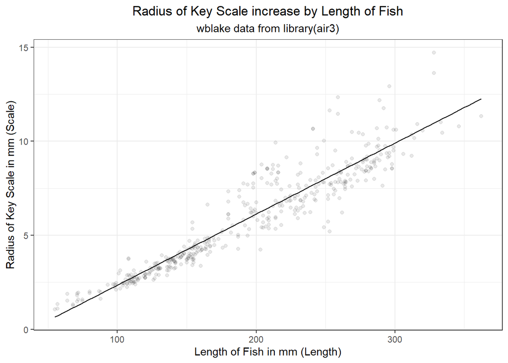

```r
wblake %>%
  ggplot(aes(y = Scale, x = Length)) +
  geom_point(alpha = .09) +
  stat_function(fun = function(x){(wblake.lm.co[1] + wblake.lm.co[2]*x)}, color = "black") +
  labs(title = "Radius of Key Scale increase by Length of Fish",
       subtitle = "wblake data from library(air3)",
       x = "Length of Fish in mm (Length)",
       y = "Radius of Key Scale in mm (Scale)") +
  theme_bw() +
  theme(plot.title = element_text(hjust = 0.5),
        plot.subtitle = element_text(hjust = 0.5)) # More ticks marks is ugly
```

```r
  # scale_x_continuous(breaks = round(seq(min(wblake$Length), max(wblake$Length), by = 0.5)),1) +
  # scale_y_continuous(breaks = round(seq(min(wblake$Scale), max(wblake$Scale), by = 0.5),1))
```

$$\underbrace{\hat{Y_i}}_\text{Estimated Fish Scale} = \overbrace{b_0}^\text{Intercept Estimate} + \overbrace{b_1}^\text{Slope Estimate} \underbrace{X_i}_\text{Length of Fish}$$

### Part (c) {done}

Diagnose the regression with a residuals vs. fitted-values plot. Determine which Y-transformation is suggested for this data.

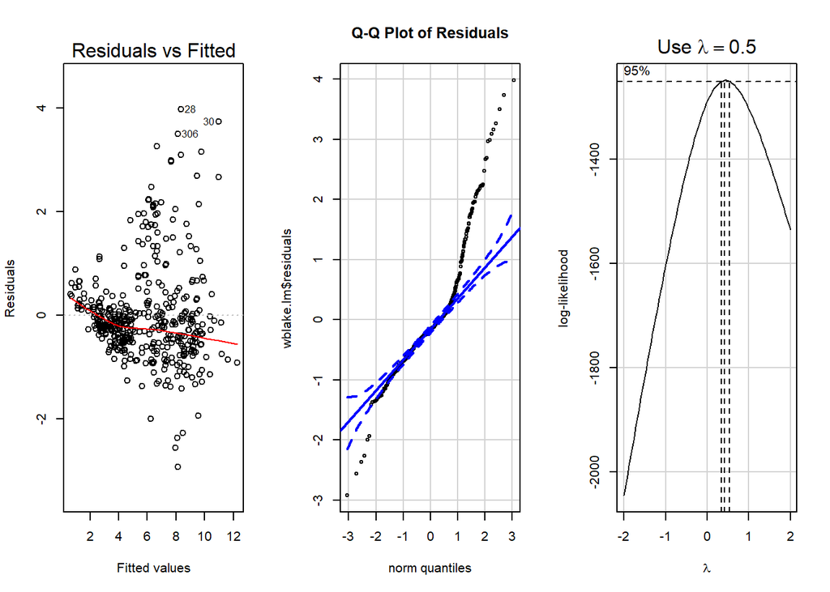

```r
# Check Assumptions
par(mfrow=c(1,3))
# plot(wblake.lm, which=1:2)
# plot(wblake.lm$residuals, main = "Residuals vs Order")
plot(wblake.lm, which = 1)
qqPlot(wblake.lm$residuals, main = "Q-Q Plot of Residuals", id = FALSE)
boxCox(wblake.lm)
mtext(side=3, text=expression(paste("Use ", lambda == 0.5)), line=.5)
```

The variance of the residuals in this data is not constant and the error terms, residuals, are not normally distributed. A boxCox() plot shows that a square root of Y will work great on the data or $\lambda = 0.5$.

### Part (d) {done}

Perform a regression of the form $Y' = Y^\lambda$. Use your answer to Part (c) to select $\lambda$.

Plot the regression in the transformed space, $Y' \sim X$ and add the fitted regression to the plot.

```r
wblake.lm.t <- lm(sqrt(Scale) ~ Length, data = wblake)
wblake.lm.t.co <- wblake.lm.t$coefficients
```

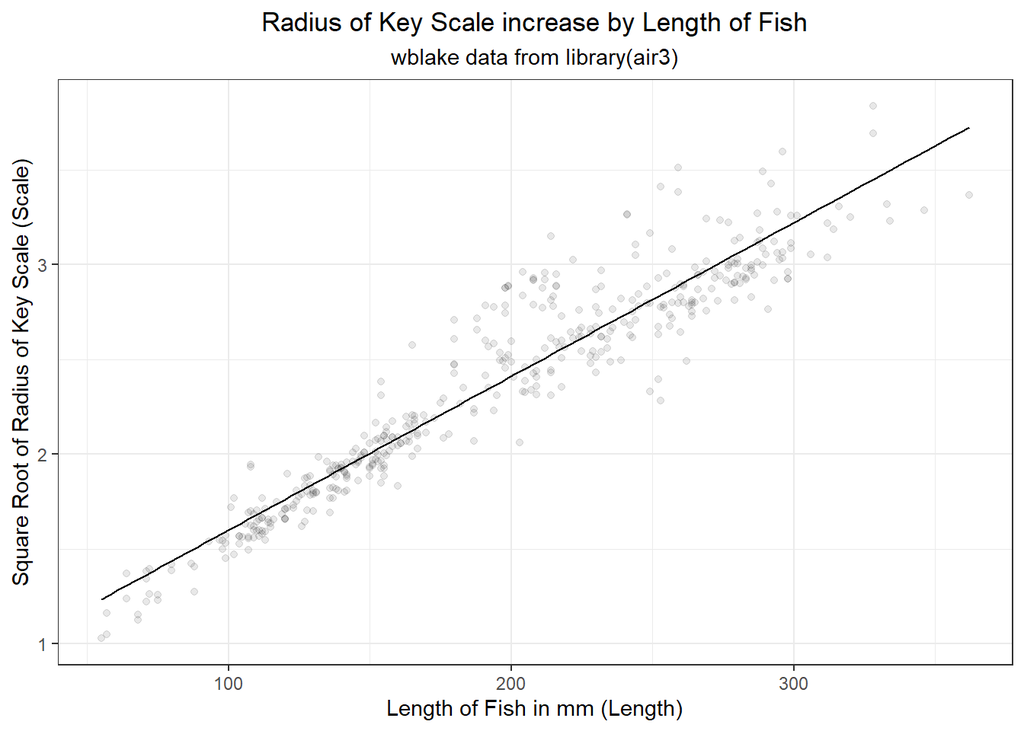

```r
wblake %>%
  ggplot(aes(y = sqrt(Scale), x = Length)) +
  geom_point(alpha = .09) +
  stat_function(fun = function(x)wblake.lm.t.co[1] + wblake.lm.t.co[2]*x,
                color = "black") +
  labs(title = "Radius of Key Scale increase by Length of Fish",
       subtitle = "wblake data from library(air3)",
       x = "Length of Fish in mm (Length)",
       y = "Square Root of Radius of Key Scale (Scale)") +
  theme_bw() +
  theme(plot.title = element_text(hjust = 0.5),
        plot.subtitle = element_text(hjust = 0.5))
```

### Part (e) {done}

State the slope, y-intercept, and $R^2$ of this transformed regression.

```r
pander(summary(wblake.lm.t))
```

|  | Estimate | Std. Error | t value | Pr(>\|t\|) |
| --- | --- | --- | --- | --- |
| **(Intercept)** | 0.7882 | 0.02638 | 29.88 | 1.164e-107 |
| **Length** | 0.008111 | 0.0001292 | 62.79 | 8.07e-221 |

Fitting linear model: sqrt(Scale) ~ Length

| Observations | Residual Std. Error | $R^2$ | Adjusted $R^2$ |
| --- | --- | --- | --- |
| 439 | 0.1806 | 0.9002 | 0.9 |

| Test | Estimate |
| --- | --- |
| Intercept | 0.7881700 |
| Slope | 0.0081115 |
| $R^2$ | 0.9002 |

### Part (f) {done}

Create a residuals vs fitted-values plot and Q-Q Plot of the residuals for this trasnformed regression. Does this regression look better than the original?

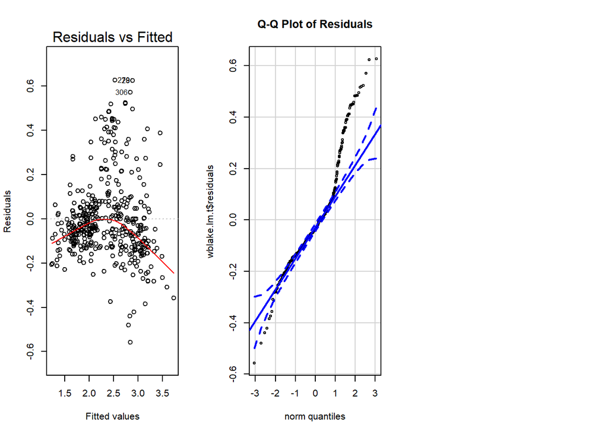

```r
# Check Assumptions
par(mfrow=c(1,3))
# plot(wblake.lm.t, which=1:2)
# plot(wblake.lm.t$residuals, main = "Residuals vs Order")
plot(wblake.lm.t, which = 1)
qqPlot(wblake.lm.t$residuals, main = "Q-Q Plot of Residuals", id = FALSE)
```

They look about the same.

### Part (g) {done}

Untransform the fitted regression equation and draw it on a scatterplot of the original data. Include the original regression line on this plot.

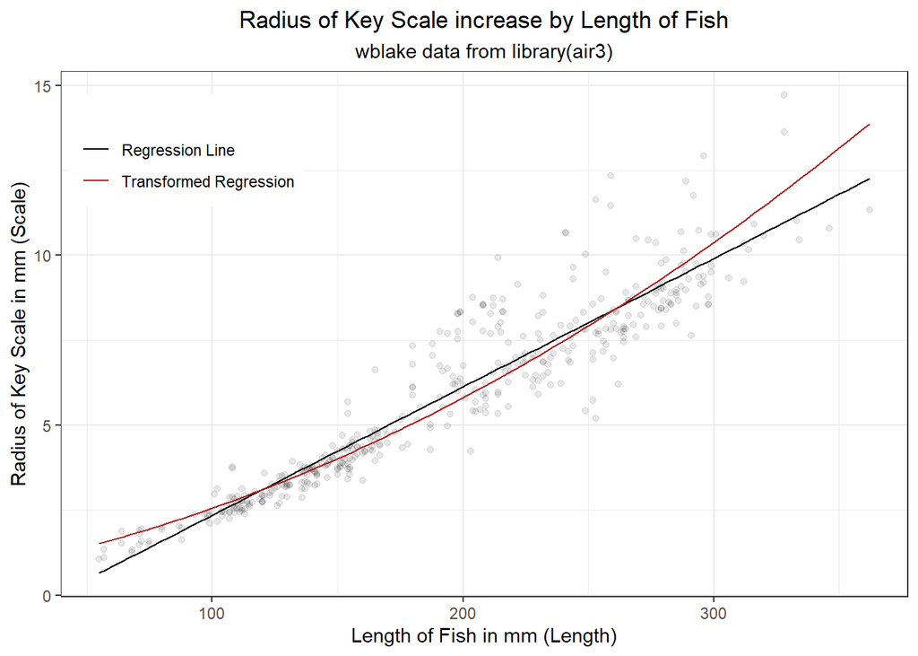

```r
wblake %>%
  ggplot(aes(y = Scale, x = Length)) +
  geom_point(alpha = .09) +
  stat_function(fun = function(x)wblake.lm.co[1] + wblake.lm.co[2]*x,
                aes(color = "a")) +
  stat_function(fun = function(x){(wblake.lm.t.co[1] + wblake.lm.t.co[2]*x)^2},
                aes(color = "b")) +
  labs(title = "Radius of Key Scale increase by Length of Fish",
       subtitle = "wblake data from library(air3)",
       x = "Length of Fish in mm (Length)",
       y = "Radius of Key Scale in mm (Scale)") +
  theme_bw() +
  theme(plot.title = element_text(hjust = 0.5),
        plot.subtitle = element_text(hjust = 0.5),
        legend.position = c(0.15, .85)) +
  scale_color_manual("",
                     values = c("black", "firebrick"),
                     labels = c("Regression Line", "Transformed Regression"))
```

### Part (h) {done}

Place two prediction intervals for the Scale radius when the Length of the fish is 250 on your scatterplot of the data in the original units.

1. Show the prediction interval from the original regression in the original units.
2. Show the prediction interval from the transformed regression back on the original units.

```r
predict(wblake.lm, data.frame(Length=250), interval="prediction")
```

```
##        fit     lwr      upr
## 1 8.019889 6.19091 9.848869
```

```r
predict(wblake.lm.t, data.frame(Length=250), interval="prediction")^2
```

```
##       fit      lwr     upr
## 1 7.93008 6.053607 10.0595
```

```r
mylines1 <- predict(wblake.lm, data.frame(Length=250), interval="prediction")
mylines <- predict(wblake.lm.t, data.frame(Length=250), interval="prediction")^2
```

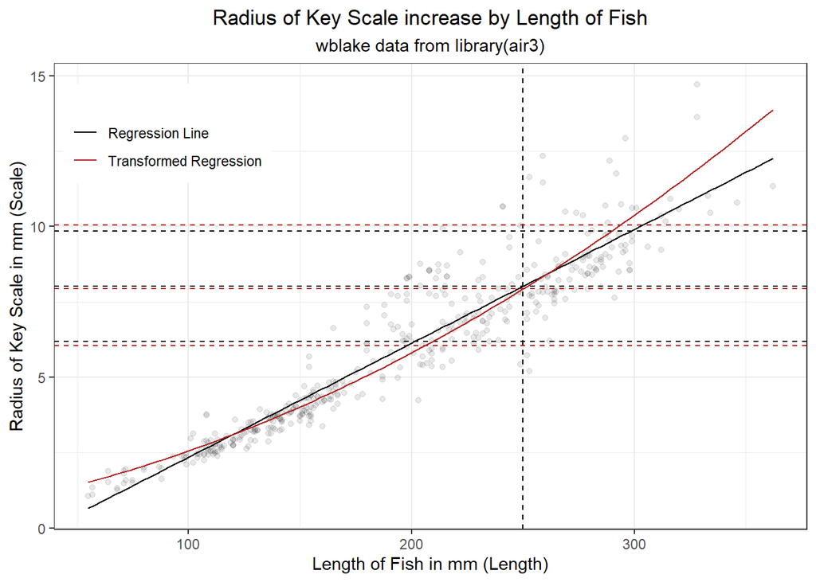

```r
wblake %>%
  ggplot(aes(y = Scale, x = Length)) +
  geom_point(alpha = .09) +
  geom_vline(xintercept = 250, color = "black", linetype = 2) +
  geom_hline(aes(yintercept = mylines1[1]), color = "black", linetype = 2) +
  geom_hline(aes(yintercept = mylines1[2]), color = "black", linetype = 2) +
  geom_hline(aes(yintercept = mylines1[3]), color = "black", linetype = 2) +
  geom_hline(aes(yintercept = mylines[1]), color = "firebrick", linetype = 2) +
  geom_hline(aes(yintercept = mylines[2]), color = "firebrick", linetype = 2) +
  geom_hline(aes(yintercept = mylines[3]), color = "firebrick", linetype = 2) +
  # geom_segment(aes(x=250, xend=250, y=mylines[2], yend=mylines[3]), color="firebrick", linetype = 2) +
  stat_function(fun = function(x)wblake.lm.co[1] + wblake.lm.co[2]*x,
                aes(color = "a")) +
  stat_function(fun = function(x){(wblake.lm.t.co[1] + wblake.lm.t.co[2]*x)^2},
                aes(color = "b")) +
  labs(title = "Radius of Key Scale increase by Length of Fish",
       subtitle = "wblake data from library(air3)",
       x = "Length of Fish in mm (Length)",
       y = "Radius of Key Scale in mm (Scale)") +
  theme_bw() +
  theme(plot.title = element_text(hjust = 0.5),
        plot.subtitle = element_text(hjust = 0.5),
        legend.position = c(0.15, .85)) +
  scale_color_manual("",
                     values = c("black", "firebrick"),
                     labels = c("Regression Line", "Transformed Regression"))
```